# Seminario Enfermedades Crónicas

Noa Martínez Aguirre, Itsaso Madrigal Román, María Alonso Mata

2024-11-27

```r
# Cargamos el paquete RPostgres
library(DBI)
library(RPostgres)

con <- dbConnect(RPostgres::Postgres(),
                 dbname = "postgres",
                 host = "localhost",
                 port = 5432,
                 user = "postgres",
                 password = "postgres")
```

# Introducción

En nuestra base de datos, se almacenan datos relativos a enfermedades crónicas y el efecto que diferentes factores de riesgo tienen sobre ellas. Para su análisis, trabajaremos con el ejemplo sintético de pacientes diagnosticados con alguna enfermedad crónica, limitadas a: - Hipertensión - Diabetes tipo II - Asma

La información utilizada para llevar a cabo esta base de datos con datos sintéticos ha sido reforzada con las siguientes fuentes:

- Datos abiertos Gob. España; Población con alguna enfermedad o problema de salud crónicos percibido según sexo, país de nacimiento y grupo de edad
- [National Library of Medicine, National Center for Biotechnology Information; Factores de Riesgo](https://pmc.ncbi.nlm.nih.gov/articles/PMC5369087/)
- [BMC Health Service Reseach; Chronic disease risk factors associated with health service use in the elderly](https://bmchealthservres.biomedcentral.com/articles/10.1186/1472-6963-8-237#Tab1)

Así, crearemos cuatro tablas:

- **Tabla Historia_Clinica**: Almacena los datos sanitarios relevantes de cada paciente.
- **Tabla Pacientes**: Guarda la información básica de cada paciente.
- **Tabla Tratamiento**: Guarda los diferentes medicamentos que pueden ser recetados a los pacientes.
- **Tabla Cita_Medica**: En ella guardamos la información de las consultas en las que se les diagnostica y receta algún medicamento.

# Objetivos

Nuestro objetivo principal es analizar la correlación entre diferentes factores de riesgo y la aparición de alguna de las enfermedades antes mencionadas, así como su tratamiento. Con este fin, nos plantearemos estas preguntas:

- **Pregunta 1**: Cada enfermedad viene con ciertos factores de riesgo que pueden afectar a su temprana aparición. ¿Cuáles son los factores de riesgo más prominentes en cada enfermedad crónica?
- **Pregunta 2**: Teniendo en cuenta que son pacientes crónicos, algunos necesitan una cita de seguimiento. Muestra una tabla en la que se asigne a cada paciente su siguiente cita antendiendo a su enfermedad (en 2 meses si tienen hipertensión, 3 si tienen diabetes y 8 si es asma). Adicionalmente, genera las citas teniendo en cuenta sus factores de riesgo.
- **Pregunta 3**: Después de llevar a cabo un estudio sobre el medicamento para la hipertensión ‘Lisinopril’, se ha descubierto que su eficacia en realidad es del 30%. Actualiza la base de datos y cambia el tratamiento de los pacientes con dicho medicamento.

# Metodología

## Tabla Historia Clínica

La tabla Historia_Clinica se encuentra en tercera forma normal. Esto se comprueba ya que está en primera forma normal puesto que las cláusulas obligan a la no repetición de tuplas y a los usos de atributos atómicos y homogéneos.

Ya estando en primera forma normal, se comprueba si está en segunda forma normal, para lo que los atributos deberán depender de las claves candidatas al completo y directamente (sin transitividad). Y teniendo en cuenta el conjunto de dependencias funcionales:

- Id_Paciente -> Multimorbilidad
- Id_Paciente -> Fumador
- Id_Paciente -> Consumo_alcohol
- Id_Paciente -> Sedentarismo
- Id_Paciente -> Antecedentes
- Id_Paciente -> Altura
- Id_Paciente -> Peso

Se comprueba que cada atributo depende completamente de una clave candidata, Id_Paciente. Por tanto, está en tercera forma normal.

Además, si nos enfocamos en la variación de la tercera forma normal, la forma normal de Boyce-Codd, nos damos cuenta de que se encuentra en esta forma normal más restrictiva puesto que Id_Paciente en el esquema de dependencias funcionales estas se encuentran siempre en el determinante.

```r
dbExecute(con, "
CREATE TABLE Historia_Clinica(
  Id_Paciente numeric(3) PRIMARY KEY,
  Altura numeric(3,2),
  Peso numeric(5,2),
  Fumador boolean,
  Consumo_alcohol numeric(1) CHECK (Consumo_alcohol<=3) DEFAULT 0,
  Sedentarismo varchar(8),
  Antecedentes boolean DEFAULT FALSE,
  Multimorbilidad boolean
);
")
```

```
## [1] 0
```

Agregamos los datos del historial médico de cada paciente

```r
# Insertar datos en 'Historia_Clinica’
dbExecute(con, "
INSERT INTO Historia_Clinica VALUES
(324, 1.75, 92, FALSE, 2, 'Leve', FALSE, TRUE),
(124, 1.52, 45.5, FALSE, 2, 'Moderado', FALSE, TRUE),
(552, 1.60, 50, FALSE, 1, 'Moderado', FALSE, FALSE),
(023, 1.85, 82, TRUE, 3, 'Leve', TRUE, FALSE),
(247, 1.90, 100, FALSE, 0, 'Moderado', FALSE, FALSE),
(398, 1.65, 76.5, FALSE, 1, 'Activo', FALSE, TRUE),
(072, 1.74, 75, FALSE, 0, 'Leve', FALSE, TRUE),
(017, 1.50, 67, FALSE, 2, 'Moderado', TRUE, FALSE),
(238, 1.62, 60, FALSE, 1, 'Activo', FALSE, FALSE),
(458, 1.94, 98, FALSE, 2, 'Leve', TRUE, FALSE),
(329, 1.79, 63.5, TRUE, 1, 'Activo', FALSE, FALSE),
(421, 1.62, 71.4, FALSE, 2, 'Moderado', TRUE, TRUE),
(312, 1.73, 90.7, FALSE, 0, 'Activo', FALSE, TRUE),
(082, 1.65, 70, FALSE, 0, 'Leve', FALSE, TRUE),
(400, 1.80, 90, TRUE, 1, 'Leve', FALSE, FALSE);
")
```

```
## [1] 15
```

Mostramos la tabla

```sql
SELECT * FROM Historia_Clinica;
```

Displaying records 1 - 10

| id_paciente | altura | peso | fumador | consumo_alcohol | sedentarismo | antecedentes | multimorbilidad |
| --- | --- | --- | --- | --- | --- | --- | --- |
| 324 | 1.75 | 92.0 | FALSE | 2 | Leve | FALSE | TRUE |
| 124 | 1.52 | 45.5 | FALSE | 2 | Moderado | FALSE | TRUE |
| 552 | 1.60 | 50.0 | FALSE | 1 | Moderado | FALSE | FALSE |
| 23 | 1.85 | 82.0 | TRUE | 3 | Leve | TRUE | FALSE |
| 247 | 1.90 | 100.0 | FALSE | 0 | Moderado | FALSE | FALSE |
| 398 | 1.65 | 76.5 | FALSE | 1 | Activo | FALSE | TRUE |
| 72 | 1.74 | 75.0 | FALSE | 0 | Leve | FALSE | TRUE |
| 17 | 1.50 | 67.0 | FALSE | 2 | Moderado | TRUE | FALSE |
| 238 | 1.62 | 60.0 | FALSE | 1 | Activo | FALSE | FALSE |
| 458 | 1.94 | 98.0 | FALSE | 2 | Leve | TRUE | FALSE |

## Tabla Pacientes

La tabla pacientes se encuentra en tercera forma normal. Esto se comprueba ya que está en primera forma normal puesto que las cláusulas obligan a la no repetición de tuplas y a los usos de atributos atómicos y homogéneos.

Ya estando en primera forma normal, se comprueba si está en segunda forma normal, para lo que los atributos deberán depender de las claves candidatas al completo y directamente (sin transitividad). Y teniendo en cuenta el conjunto de dependencias funcionales:

- Id_Paciente -> Nombre
- Id_Paciente -> DNI
- Id_Paciente -> Edad
- Id_Paciente -> Sexo
- DNI -> Id_Paciente
- DNI -> Nombre
- DNI -> Edad
- DNI -> Sexo

Se comprueba que cada atributo depende completamente de una clave candidata, ya sea, Id_Paciente o DNI.

Además, se comprueba que los atributos que no pertenecen a la clave candidata dependen total e íntegramente de ella, ya sea directamente o con una dependencia cíclica como ocurre con Id_Paciente y DNI. Por tanto, está en tercera forma normal.

Si nos enfocamos en la variación de la tercera forma normal, la forma normal de Boyce-Codd, nos damos cuenta de que se encuentra en esta forma normal más restrictiva puesto que tanto Id_Paciente como DNI (las dos claves candidatas) en el esquema de dependencias funcionales estas se encuentran siempre (exceptuando las suyas propias) en el determinante.

```r
dbExecute(con, "
CREATE TABLE Pacientes (
  DNI   char(9) PRIMARY KEY,
  Nombre varchar(30) NOT NULL,
  Edad numeric(3) CHECK (Edad >= 0),
  Sexo char(1),
  Id_Paciente numeric(3) UNIQUE NOT NULL REFERENCES Historia_Clinica
);
")
```

```
## [1] 0
```

Ahora agregamos relativos a los datos de los pacientes

```r
# Insertar datos en 'pacientes'
dbExecute(con, "
INSERT INTO Pacientes (Id_Paciente, DNI, nombre, edad, sexo) VALUES
(324, '16734932J', 'Juan Castrillo', 28, 'H'),
(124, '34788900M', 'Elsa Suárez', 80, 'M'),
(552, '22998017K', 'Beatriz De La Puebla', 67, 'M'),
(023, '34355078F', 'Jon Astorga', 16, 'H'),
(247, '37389518G', 'David Rodas', 19, 'H'),
(398, '98395856L', 'Antonio Cantero', 47, 'H'),
(072, '03475273G', 'Juan Lucas Izquierdo', 31, 'H'),
(017, '20967356P', 'Dolores Aguirre', 76, 'M'),
(238, '75623934A', 'Yolanda Pérez', 40, 'M'),
(458, '58750439M', 'Roberto Cantero', 51, 'H'),
(329, '21874914C', 'Sandra Martínez', 34, 'M'),
(421, '10260094S', 'Margarita Salinas', 82, 'M'),
(312, '28977568D', 'Vega Cámara', 33, 'M'),
(082, '98933385S', 'Asunción Miedel', 69, 'M'),
(400, '38758485E', 'Lucas Riego', 16, 'H');
")
```

```
## [1] 15
```

Mostramos la tabla

```sql
SELECT * FROM pacientes;
```

Displaying records 1 - 10

| dni | nombre | edad | sexo | id_paciente |
| --- | --- | --- | --- | --- |
| 16734932J | Juan Castrillo | 28 | H | 324 |
| 34788900M | Elsa Suárez | 80 | M | 124 |
| 22998017K | Beatriz De La Puebla | 67 | M | 552 |
| 34355078F | Jon Astorga | 16 | H | 23 |
| 37389518G | David Rodas | 19 | H | 247 |
| 98395856L | Antonio Cantero | 47 | H | 398 |
| 03475273G | Juan Lucas Izquierdo | 31 | H | 72 |
| 20967356P | Dolores Aguirre | 76 | M | 17 |
| 75623934A | Yolanda Pérez | 40 | M | 238 |
| 58750439M | Roberto Cantero | 51 | H | 458 |

## Tratamientos

La tabla Tratamientos se encuentra en tercera forma normal. Esto se comprueba ya que está en primera forma normal puesto que las cláusulas obligan a la no repetición de tuplas y a los usos de atributos atómicos y homogéneos.

Ya estando en primera forma normal, se comprueba si está en segunda forma normal, para lo que los atributos deberán depender de las claves candidatas al completo y directamente (sin transitividad). Y teniendo en cuenta el conjunto de dependencias funcionales:

- Cod_medicamento -> Medicamento, Función, Dosis_diaria, Eficacia
- Medicamento -> Cod_medicamento, Función, Dosis_diaria, Eficacia

Se comprueba que cada atributo depende completamente de una clave candidata, ya sea, Medicamento o Cod_medicamento.

Además, se comprueba que los atributos que no pertenecen a la clave candidata dependen total e íntegramente de ella, ya sea directamente o con una dependencia cíclica como ocurre con Medicamento y Cod_medicamento. Por tanto, está en tercera forma normal.

Si nos enfocamos en la variación de la tercera forma normal, la forma normal de Boyce-Codd, nos damos cuenta de que se encuentra en esta forma normal más restrictiva puesto que tanto Medicamento como Cod_medicamento (las dos claves candidatas) en el esquema de dependencias funcionales estas se encuentran siempre (exceptuando las suyas propias) en el determinante.

```r
dbExecute(con, "
CREATE TABLE Tratamiento(
  Cod_receta integer PRIMARY KEY,
  Medicamento varchar(20) UNIQUE NOT NULL,
  Funcion varchar(20),
  Dosis_diaria smallint,
  Eficacia integer
);
")
```

```
## [1] 0
```

Ahora, agregaremos los datos de cada medicación recetada

```r
# Insertar datos en 'Tratamiento’
dbExecute(con, "
INSERT INTO Tratamiento VALUES
(12387456, 'Losartan', 'Vasodilatador', 50, 65),
(74889598, 'Salbutamol', 'Broncodilatador', 100, 85),
(64759834, 'Staticum', 'Antidiabético', 20, 87),
(93498589, 'Clortalidona', 'Diurético', 50, 70),
(34859845, 'Beclometasona', 'Corticosteroles', 40, 56),
(98475984, 'Formoterol', 'Broncodilatador', 100, 70),
(72777984, 'Diamicron', 'Hipoglucemiante', 80, 70),
(28359948, 'Dapagliflozina', 'Aumenta sodio', 5, 69),
(38457384, 'Lisinopril', 'Vasodilatador', 10, 65);
")
```

```
## [1] 9
```

Mostramos la tabla

```sql
SELECT * FROM Tratamiento;
```

9 records

| cod_receta | medicamento | funcion | dosis_diaria | eficacia |
| --- | --- | --- | --- | --- |
| 12387456 | Losartan | Vasodilatador | 50 | 65 |
| 74889598 | Salbutamol | Broncodilatador | 100 | 85 |
| 64759834 | Staticum | Antidiabético | 20 | 87 |
| 93498589 | Clortalidona | Diurético | 50 | 70 |
| 34859845 | Beclometasona | Corticosteroles | 40 | 56 |
| 98475984 | Formoterol | Broncodilatador | 100 | 70 |
| 72777984 | Diamicron | Hipoglucemiante | 80 | 70 |
| 28359948 | Dapagliflozina | Aumenta sodio | 5 | 69 |
| 38457384 | Lisinopril | Vasodilatador | 10 | 65 |

## Tabla Cita Médica

La tabla Cita_Medica se encuentra en primera forma normal. Esto se comprueba ya que cumple esta forma puesto que las cláusulas obligan a la no repetición de tuplas y a los usos de atributos atómicos y homogéneos. Pero no todos los atributos dependen completamente de la clave primaria. Siendo el esquema de dependencias funcionales:

- Doctor -> Servicio
- Fecha_Hora, Id_paciente -> Doctor
- Fecha_hora, Id_Paciente -> Prescripción
- Fecha_hora, Id_Paciente -> Diagnóstico

En la que, si bien es posible determinar todos los determinados con Fecha_Hora y Id_paciente, hay atributos que no dependen completamente de la tabla y, además, hay atributos cuya determinación es mediante transitividad.

```r
dbExecute(con, "
CREATE TABLE Cita_Medica(
  Fecha_hora timestamp CHECK (Fecha_hora < current_timestamp),
  Id_paciente numeric(3) REFERENCES Historia_Clinica,
  Doctor char(50) NOT NULL,
  Diagnostico varchar(15),
  Servicio varchar(20),
  Prescripcion integer REFERENCES Tratamiento(Cod_receta),
  PRIMARY KEY (Fecha_hora, Id_paciente)
);
")
```

```
## [1] 0
```

Ahora agregamos los datos de la consulta en la que se les diagnosticó

```r
# Insertar datos en 'Consulta_Medica’
dbExecute(con, "
INSERT INTO Cita_Medica VALUES
('08-11-2024 8:40', 017, 'Sofía González', 'Diabetes II', 'Medicina interna', 72777984),
('08-17-2024 9:30', 023, 'Mateo Ramírez', 'Hipertensión', 'Cardiologia', 93498589),
('09-02-2024 12:10', 238, 'Elena García', 'Asma', 'Neumologia', 98475984),
('09-09-2024 9:00', 247, 'Lucas Fernández', 'Hipertensión', 'Cardiologia', 38457384),
('09-11-2024 11:50', 312, 'Mateo Ramírez', 'Diabetes II', 'Medicina interna', 64759834),
('09-18-2024 8:30', 552, 'Mateo Ramírez', 'Diabetes II', 'Medicina interna', 28359948),
('09-20-2024 13:25', 082, 'Lucas Fernández', 'Asma', 'Neumologia', 74889598),
('09-25-2024 11:30', 458, 'Camila Morales', 'Hipertensión', 'Cardiologia', 38457384),
('10-07-2024 10:15', 324, 'Elena García', 'Diabetes II', 'Medicina interna', 72777984),
('10-12-2024 10:45', 400, 'Camila Morales', 'Asma', 'Neumologia', 98475984),
('10-23-2024 8:25', 329, 'Lucas Fernández', 'Asma', 'Neumologia', 34859845),
('10-28-2024 9:50', 398, 'Camila Morales', 'Hipertensión', 'Cardiologia', 12387456),
('11-09-2024 12:30', 072, 'Mateo Ramírez', 'Diabetes II', 'Medicina interna', 64759834),
('11-15-2024 14:00', 421, 'Sofía González', 'Hipertensión', 'Cardiologia', 12387456),
('11-20-2024 11:15', 124, 'Elena García', 'Asma', 'Neumologia', 74889598);
")
```

```
## [1] 15
```

Mostramos la tabla

```sql
SELECT * FROM Cita_Medica;
```

Displaying records 1 - 10

| fecha_hora | id_paciente | doctor | diagnostico | servicio | prescripcion |
| --- | --- | --- | --- | --- | --- |
| 2024-08-11 08:40:00 | 17 | Sofía González | Diabetes II | Medicina interna | 72777984 |
| 2024-08-17 09:30:00 | 23 | Mateo Ramírez | Hipertensión | Cardiologia | 93498589 |
| 2024-09-02 12:10:00 | 238 | Elena García | Asma | Neumologia | 98475984 |
| 2024-09-09 09:00:00 | 247 | Lucas Fernández | Hipertensión | Cardiologia | 38457384 |
| 2024-09-11 11:50:00 | 312 | Mateo Ramírez | Diabetes II | Medicina interna | 64759834 |
| 2024-09-18 08:30:00 | 552 | Mateo Ramírez | Diabetes II | Medicina interna | 28359948 |
| 2024-09-20 13:25:00 | 82 | Lucas Fernández | Asma | Neumologia | 74889598 |
| 2024-09-25 11:30:00 | 458 | Camila Morales | Hipertensión | Cardiologia | 38457384 |
| 2024-10-07 10:15:00 | 324 | Elena García | Diabetes II | Medicina interna | 72777984 |
| 2024-10-12 10:45:00 | 400 | Camila Morales | Asma | Neumologia | 98475984 |

Con estas tablas ya completas, nos quedaría un esquema relacional tal como este:

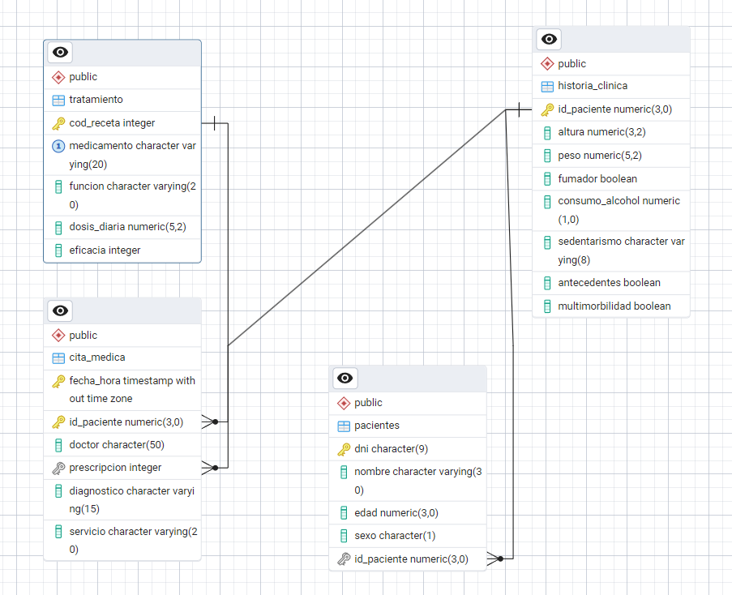

# Resultados

## Pregunta 1

¿Cuáles son los factores de riesgo más prominentes en los pacientes con cada enfermedad, y qué porcentaje de los pacientes los presentan?

```sql
SELECT Cita_Medica.Diagnostico,
    COUNT(CASE
        WHEN Historia_clinica.Peso / (Historia_clinica.Altura*Historia_clinica.Altura) > 25 THEN 'Sobrepeso'
    END)*100 / COUNT(*) as IMC_elevado,
    COUNT(CASE
        WHEN Historia_clinica.Fumador = TRUE THEN 'Sí'
    END)*100 / COUNT(*) as Fumadores,
    COUNT(CASE
        WHEN Historia_clinica.Consumo_alcohol > 1 THEN 'Alto riesgo'
    END)*100 / COUNT(*) as Consumo_alcohol_alto,
    COUNT(CASE
        WHEN Historia_clinica.Sedentarismo = 'Moderado' OR Historia_clinica.Sedentarismo = 'Severo' THEN 'Sí'
    END)*100 / COUNT(*) as Sedentarios,
    COUNT(CASE
        WHEN Historia_clinica.Antecedentes = TRUE THEN 'Sí'
    END)*100 / COUNT(*) as Antecedentes_familiares,
    COUNT(CASE
        WHEN Historia_clinica.Multimorbilidad = TRUE THEN 'Otras patologías relacionadas'
    END)*100 / COUNT(*) as Comorbilidad
FROM Cita_Medica JOIN Historia_Clinica USING (Id_paciente)
GROUP BY Cita_Medica.Diagnostico;
```

3 records

| diagnostico | imc_elevado | fumadores | consumo_alcohol_alto | sedentarios | antecedentes_familiares | comorbilidad |
| --- | --- | --- | --- | --- | --- | --- |
| Hipertensión | 80 | 20 | 60 | 40 | 60 | 40 |
| Asma | 40 | 40 | 20 | 20 | 0 | 40 |
| Diabetes II | 60 | 0 | 40 | 40 | 20 | 60 |

## Pregunta 2

Asigna a cada paciente una cita de seguimiento atendiendo a su enfermedad (en 2 meses a aquellos que padezcan hipertensión, en 3 si es diabetes, en 8 si es asma). Además, añade la frecuencia de las citas atendiendo a los diferentes factores de riesgo.

Primero, asignaremos la cita de seguimiento a cada paciente:

```sql
ALTER TABLE Cita_Medica
ADD COLUMN proxima_cita  timestamp CHECK (fecha_hora < proxima_cita);
```

```sql
UPDATE Cita_Medica
SET proxima_cita = Fecha_hora + cast('8 month' as interval) WHERE Diagnostico= 'Asma';
```

```sql
UPDATE Cita_Medica
SET proxima_cita = Fecha_hora + cast('3 month' as interval) WHERE Diagnostico= 'Diabetes II';
```

```sql
UPDATE Cita_Medica
SET proxima_cita = Fecha_hora + cast('2 month' as interval) WHERE Diagnostico= 'Hipertensión';
```

```sql
SELECT id_paciente, proxima_cita FROM cita_medica;
```

Displaying records 1 - 10

| id_paciente | proxima_cita |
| --- | --- |
| 238 | 2025-05-02 12:10:00 |
| 82 | 2025-05-20 13:25:00 |
| 400 | 2025-06-12 10:45:00 |
| 329 | 2025-06-23 08:25:00 |
| 124 | 2025-07-20 11:15:00 |
| 17 | 2024-11-11 08:40:00 |
| 312 | 2024-12-11 11:50:00 |
| 552 | 2024-12-18 08:30:00 |
| 324 | 2025-01-07 10:15:00 |
| 72 | 2025-02-09 12:30:00 |

Después, ya se tomará en cuenta los factores de riesgo que presente para acercar más o menos las citas:

```sql
CREATE VIEW aspecto AS
SELECT Cita_Medica.proxima_cita, Historia_Clinica.*
FROM Cita_Medica JOIN Historia_Clinica USING (Id_Paciente);
```

```sql
SELECT id_paciente,
    CASE
        WHEN Consumo_alcohol = 3
            THEN proxima_cita - cast('20 days' as interval)
        when Consumo_alcohol = 2
            THEN proxima_cita - cast('15 days' as interval)
        when Consumo_alcohol = 1
            THEN proxima_cita - cast('10 days' as interval)
        when Consumo_alcohol = 0
            THEN proxima_cita - cast('7 days' as interval)
    END AS proxima
    FROM aspecto where ((Peso / (Altura * Altura) > 25) OR (Peso / (Altura * Altura) < 18));
```

9 records

| id_paciente | proxima |
| --- | --- |
| 82 | 2025-05-13 13:25:00 |
| 400 | 2025-06-02 10:45:00 |
| 17 | 2024-10-27 08:40:00 |
| 312 | 2024-12-04 11:50:00 |
| 324 | 2024-12-23 10:15:00 |
| 247 | 2024-11-02 09:00:00 |
| 458 | 2024-11-10 11:30:00 |
| 398 | 2024-12-18 09:50:00 |
| 421 | 2024-12-31 14:00:00 |

## Pregunta 3

Depués de llevar a cabo un estudio sobre el medicamento para la hipertensión, ‘Lisinopril’, se ha descubierto que su eficacia en realidad es del 30%. Actualiza la base de datos y cambia el tratamiento de los pacientes con dicho medicamento.

```sql
UPDATE Tratamiento
SET Eficacia = 30
WHERE Cod_receta = 38457384;
```

```sql
UPDATE Cita_Medica
SET Prescripcion = 93498589
WHERE Prescripcion = 38457384;
```

```sql
SELECT Cita_Medica.Id_Paciente, Prescripcion, Diagnostico, Eficacia
FROM Cita_Medica RIGHT OUTER JOIN Tratamiento ON (Cita_Medica.Prescripcion = Tratamiento.Cod_receta);
```

Displaying records 1 - 10

| id_paciente | prescripcion | diagnostico | eficacia |
| --- | --- | --- | --- |
| 238 | 98475984 | Asma | 70 |
| 82 | 74889598 | Asma | 85 |
| 400 | 98475984 | Asma | 70 |
| 329 | 34859845 | Asma | 56 |
| 124 | 74889598 | Asma | 85 |
| 17 | 72777984 | Diabetes II | 70 |
| 312 | 64759834 | Diabetes II | 87 |
| 552 | 28359948 | Diabetes II | 69 |
| 324 | 72777984 | Diabetes II | 70 |
| 72 | 64759834 | Diabetes II | 87 |

# Finalizando el documento…

Para finalizar el documento, creamos un código que nos permita **borrar todas las tablas creadas**.

```r
# Obtenemos la lista de todas las tablas en la base de datos
tables <- dbListTables(con)
print(tables)
```

```
## [1] "cita_medica"      "historia_clinica" "pacientes"        "tratamiento"
## [5] "aspecto"
```

```r
# Borra todas las tablas
for (table in tables) {
  dbExecute(con, paste0("DROP TABLE IF EXISTS ", table, " CASCADE;"))
}

# Verifica que no queden tablas
tables_after <- dbListTables(con)
print(tables_after)
```

```
## character(0)
```

Finalmente, desconectamos la base de datos local.

```r
dbDisconnect(con)
```